# Diamonds ML R Notebook

Diamonds ML R Notebook Robert M. Taylor, PhD

This notebook is to demonstrate Exploratory Data Analysis (EDA), visualizations, and machine learning in R on the diamonds dataset that is available in R. “Price” will be our target.s

I’ll first import the libraries I’ll use.

```r
library(ggplot2)
library(GGally)
library(rpart)
library(randomForest)
library(tidyr)
library(modelr)
```

Load the dataset

```r
data(diamonds)
```

I’ll just look at/inspect the dataset first. This is a clean data set so data cleaning will not be needed or demonstrated in this notebook.

```r
head(diamonds)
```

| carat | cut | color | clarity | depth | table | price | x | y | z |
| --- | --- | --- | --- | --- | --- | --- | --- | --- | --- |
| 0.23 | Ideal | E | SI2 | 61.5 | 55 | 326 | 3.95 | 3.98 | 2.43 |
| 0.21 | Premium | E | SI1 | 59.8 | 61 | 326 | 3.89 | 3.84 | 2.31 |
| 0.23 | Good | E | VS1 | 56.9 | 65 | 327 | 4.05 | 4.07 | 2.31 |
| 0.29 | Premium | I | VS2 | 62.4 | 58 | 334 | 4.20 | 4.23 | 2.63 |
| 0.31 | Good | J | SI2 | 63.3 | 58 | 335 | 4.34 | 4.35 | 2.75 |
| 0.24 | Very Good | J | VVS2 | 62.8 | 57 | 336 | 3.94 | 3.96 | 2.48 |

What are the dimensions of the dataset?

```r
dim(diamonds)
```

```
## [1] 53940    10
```

So there are 53,940 rows and 10 feature columns.

I’ll now get 1) a summary and 2) the structure of the data…

```r
summary(diamonds)
```

```
##      carat               cut        color        clarity          depth
##  Min.   :0.2000   Fair     : 1610   D: 6775   SI1    :13065   Min.   :43.00
##  1st Qu.:0.4000   Good     : 4906   E: 9797   VS2    :12258   1st Qu.:61.00
##  Median :0.7000   Very Good:12082   F: 9542   SI2    : 9194   Median :61.80
##  Mean   :0.7979   Premium  :13791   G:11292   VS1    : 8171   Mean   :61.75
##  3rd Qu.:1.0400   Ideal    :21551   H: 8304   VVS2   : 5066   3rd Qu.:62.50
##  Max.   :5.0100                     I: 5422   VVS1   : 3655   Max.   :79.00
##                                     J: 2808   (Other): 2531
##      table           price             x                y
##  Min.   :43.00   Min.   :  326   Min.   : 0.000   Min.   : 0.000
##  1st Qu.:56.00   1st Qu.:  950   1st Qu.: 4.710   1st Qu.: 4.720
##  Median :57.00   Median : 2401   Median : 5.700   Median : 5.710
##  Mean   :57.46   Mean   : 3933   Mean   : 5.731   Mean   : 5.735
##  3rd Qu.:59.00   3rd Qu.: 5324   3rd Qu.: 6.540   3rd Qu.: 6.540
##  Max.   :95.00   Max.   :18823   Max.   :10.740   Max.   :58.900
##
##        z
##  Min.   : 0.000
##  1st Qu.: 2.910
##  Median : 3.530
##  Mean   : 3.539
##  3rd Qu.: 4.040
##  Max.   :31.800
##
```

I see that there is an (Other) variable for Clarity. I want to look at that closer.

```r
unique(diamonds$clarity)
```

```
## [1] SI2  SI1  VS1  VS2  VVS2 VVS1 I1   IF
## Levels: I1 < SI2 < SI1 < VS2 < VS1 < VVS2 < VVS1 < IF
```

So, everything appears good. The summary has just grouped the I1 and IF clarities in the count values in the summary table above.

We also see that the price ranges from a minimium price of $326 to a max of $18,823

I’ll go ahead and look at the structure of the dataset…

```r
str(diamonds)
```

```
## tibble [53,940 × 10] (S3: tbl_df/tbl/data.frame)
##  $ carat  : num [1:53940] 0.23 0.21 0.23 0.29 0.31 0.24 0.24 0.26 0.22 0.23 ...
##  $ cut    : Ord.factor w/ 5 levels "Fair"<"Good"<..: 5 4 2 4 2 3 3 3 1 3 ...
##  $ color  : Ord.factor w/ 7 levels "D"<"E"<"F"<"G"<..: 2 2 2 6 7 7 6 5 2 5 ...
##  $ clarity: Ord.factor w/ 8 levels "I1"<"SI2"<"SI1"<..: 2 3 5 4 2 6 7 3 4 5 ...
##  $ depth  : num [1:53940] 61.5 59.8 56.9 62.4 63.3 62.8 62.3 61.9 65.1 59.4 ...
##  $ table  : num [1:53940] 55 61 65 58 58 57 57 55 61 61 ...
##  $ price  : int [1:53940] 326 326 327 334 335 336 336 337 337 338 ...
##  $ x      : num [1:53940] 3.95 3.89 4.05 4.2 4.34 3.94 3.95 4.07 3.87 4 ...
##  $ y      : num [1:53940] 3.98 3.84 4.07 4.23 4.35 3.96 3.98 4.11 3.78 4.05 ...
##  $ z      : num [1:53940] 2.43 2.31 2.31 2.63 2.75 2.48 2.47 2.53 2.49 2.39 ...
```

I’ll now look at caret vs price using ggplot2

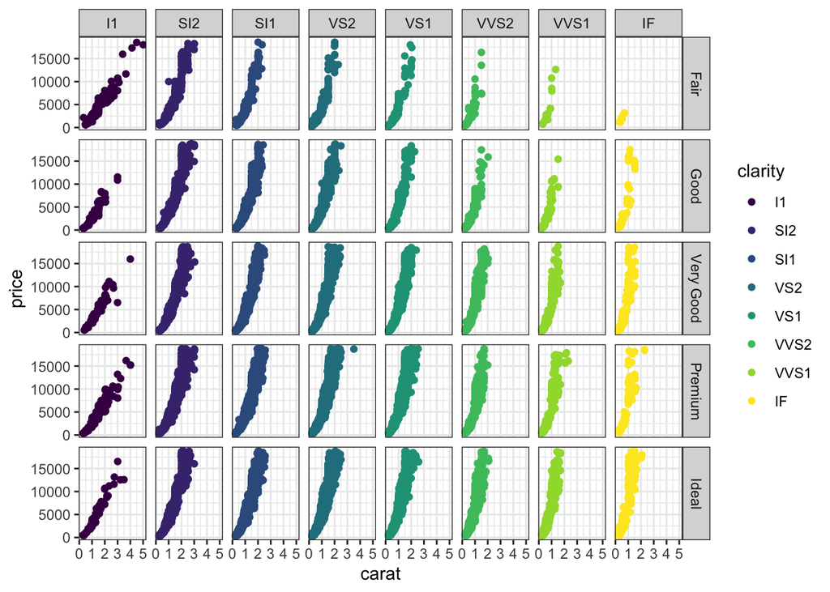

```r
g <- ggplot(diamonds, aes(x=carat, y=price))
g +
  geom_point(aes(color=clarity)) +
  facet_grid(cut ~ clarity)+
  theme_bw()
```

I’ll use a boxplot to look at cut vs. price.

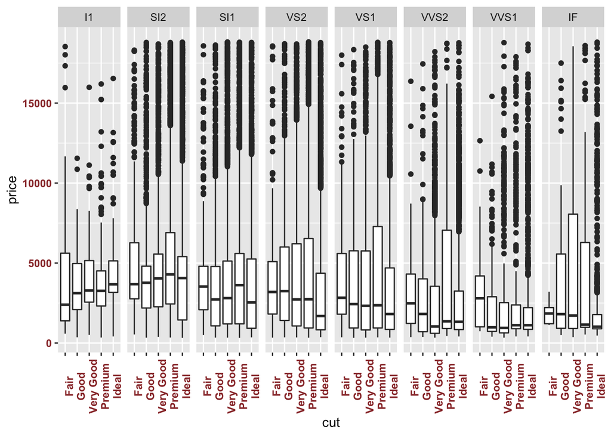

```r
diamonds$cut = as.factor(diamonds$cut)
g <- ggplot(diamonds, aes(x=cut, y=price))
g +
  geom_boxplot()+
  facet_grid(~clarity)+
  theme(axis.text.x = element_text(angle = 90, face = "bold", color = "#993333",
                           size = 9))+
  theme(axis.text.y = element_text(face = "bold", color = "#993333"))
```

We can also look at the carat vs. color vs. price

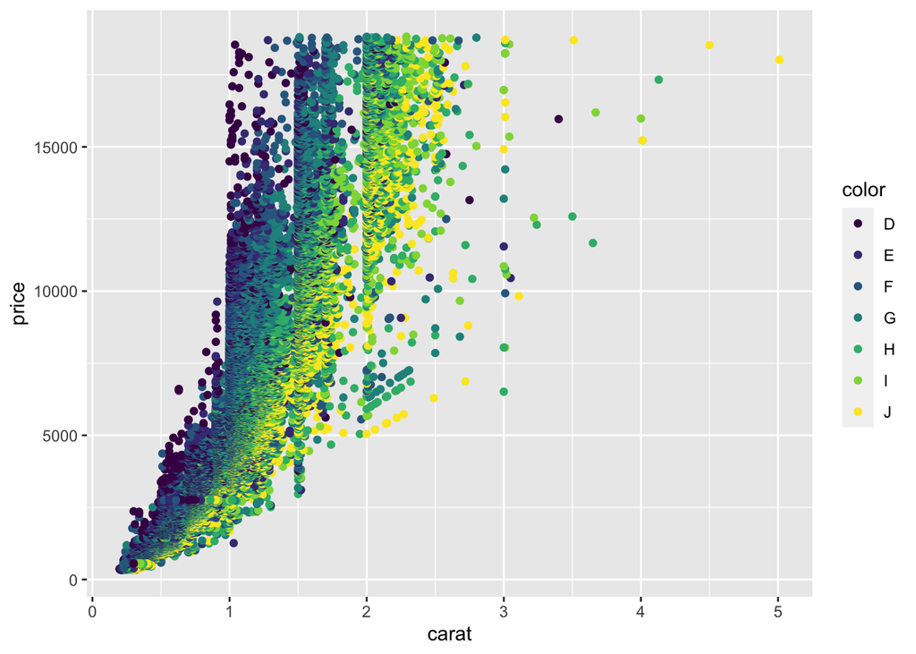

```r
g <- ggplot(diamonds, aes(x=carat, y=price))
g +
geom_point(aes(color = color))
```

I’ll now look at the distribution of carat and price.

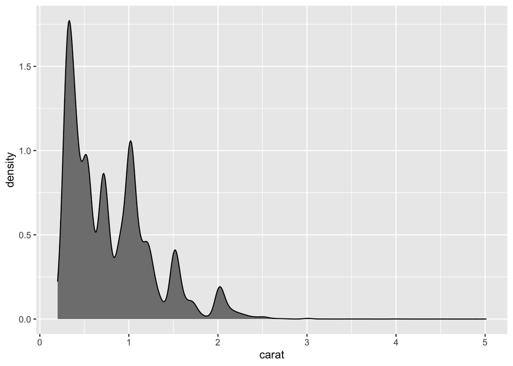

```r
g <- ggplot(diamonds)
g +
  geom_density(aes(x=carat), fill="gray50")
```

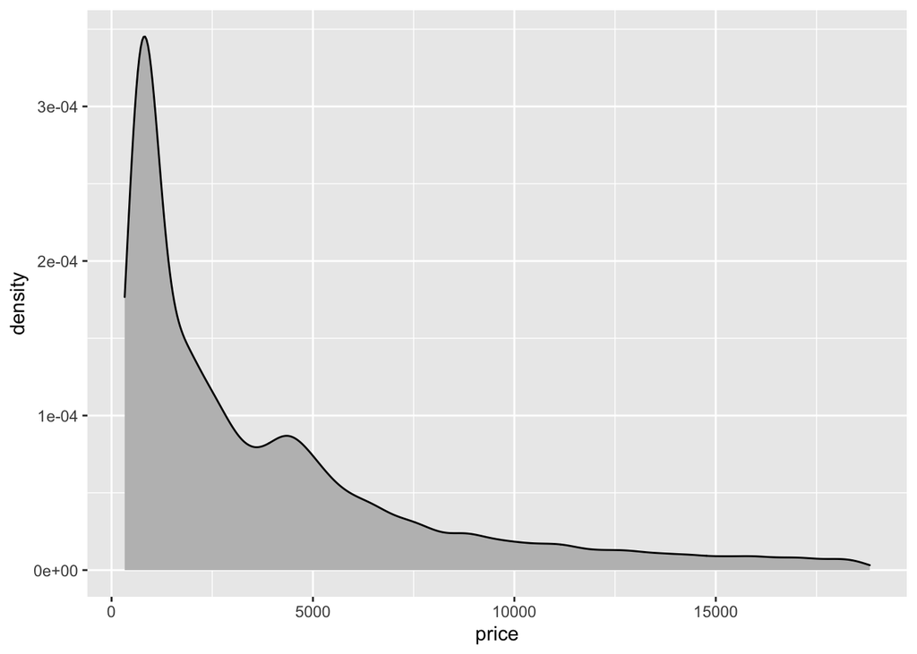

```r
g <- ggplot(diamonds)
g +
  geom_density(aes(x=price), fill="gray")
```

So, thus far, we can now see that most diamonds are < 2 carats and < ~$2500 (although a second peak can be seen around $4000).

M.L.

DECISION TREE BUILD MODEL I’ll first use a decision tree model to predict the diamond prices.

```r
colnames(diamonds)
```

```
##  [1] "carat"   "cut"     "color"   "clarity" "depth"   "table"   "price"
##  [8] "x"       "y"       "z"
```

SPLIT THE DATA (70/30 split)

```r
splitData <- resample_partition(diamonds, c(test=0.3, train=0.7))
```

How many cases are in the test and training sets?

```r
lapply(splitData, dim)
```

```
## $test
## [1] 16181    10
##
## $train
## [1] 37759    10
```

```r
# train the tree
fit <- rpart(price ~ carat + cut + color + clarity + depth + table + x + y + z, data = splitData$train)
```

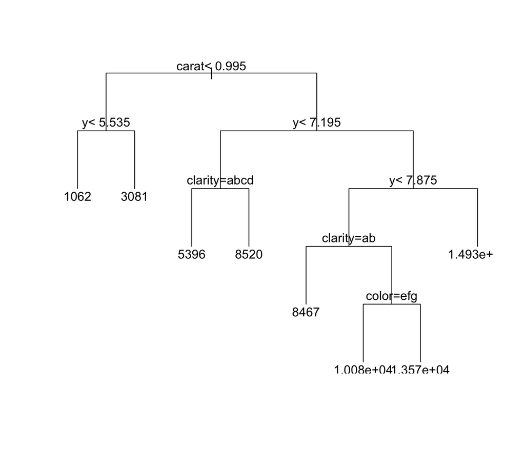

```r
#plot the regression tree
plot(fit, uniform=TRUE)
text(fit, cex=1)
```

…What if we reomive the x, y, z, data, and table features? These above group are features that are not easily available to the common consumer, like me shopping for a new ring. Therefore, I’ll see how the fit is with only the readily available features, carat, cut, color, and clarity.

```r
# train the tree
fit2 <- rpart(price ~ carat + cut + color + clarity, data = splitData$train)
```

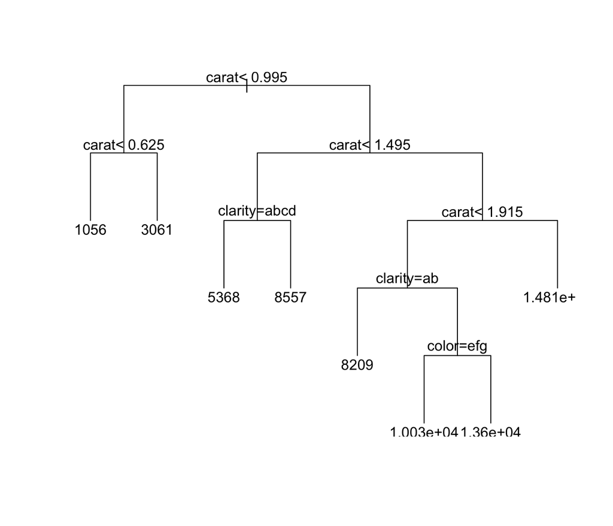

```r
#plot the regression tree
plot(fit2, uniform=TRUE)
text(fit2, cex=1)
```

I’LL USE THE ‘fit2’ MODEL SINCE IT MAKES MORE SENSE FOR MY ENGAGEMENT RING SHOPPING SINCE CARAET, CLARITY, ETC ARE THINGS I CAN EASILY FIND OUT FROM A SELLAR, WHEREAS ’x, y, and z’ARE NOT.

DECISION TREE MODEL PREDICT DIAMOND PRICES Now, that I’ve generated a decision tree model, I’ll now use it to predict prices.

DECISION TREE MODEL EVALUATION

MAE (Mean absolute Error)

```r
maeTree <-mae(model = fit2, data=splitData$test)
maeTree
```

```
## [1] 838.5041
```

I’ll build a function to help compare MAE scores from different values for the tree depth (maxdepth)…

```r
# A function to get the maximum average error for a given max depth. You should pass in
# the target as the name of the target colum and the predictors as vector where each
# item in the vector is the name of the column.

get_mae <- function(maxdepth, target, predictors, training_data, testing_data){
  #turn the predictors & target into a formula to pass to rpart
  predictors <- paste(predictors, collapse='+')
  formula <- as.formula(paste(target, "~", predictors, sep = ""))
  #build our model
  model <- rpart(formula, data=training_data, control = rpart.control(maxdepth = maxdepth))
  #get the mae
  mae <- mae(model, testing_data)
  return(mae)
}
```

```r
#Feed in the target and predictors
target <- "price"
predictors <- c("carat", "cut", "color", "clarity")
# get the MaE for the maxdepths between 1 and 10
for(i in 1:10){
  mae <- get_mae(maxdepth = i, target = target, predictors = predictors,
                 training_data = splitData$train, testing_data = splitData$test)
  print(glue::glue("Maxdepth: ",i, "\t MAE: ", mae))
}
```

```
## Maxdepth: 1   MAE: 1741.35603034843
## Maxdepth: 2   MAE: 1043.59062202845
## Maxdepth: 3   MAE: 891.038835479389
## Maxdepth: 4   MAE: 867.60728046281
## Maxdepth: 5   MAE: 838.504125609036
## Maxdepth: 6   MAE: 838.504125609036
## Maxdepth: 7   MAE: 838.504125609036
## Maxdepth: 8   MAE: 838.504125609036
## Maxdepth: 9   MAE: 838.504125609036
## Maxdepth: 10  MAE: 838.504125609036
```

RANDOM FOREST

```r
fitRandomForest <- randomForest(price ~ carat + cut + color + clarity, data=splitData$train)
maeForest <- mae(model = fitRandomForest, data=splitData$test)
maeForest
```

```
## [1] 900.7853
```

```r
fitRandomForest
```

```
##
## Call:
##  randomForest(formula = price ~ carat + cut + color + clarity,      data = splitData$train)
##                Type of random forest: regression
##                      Number of trees: 500
## No. of variables tried at each split: 1
##
##           Mean of squared residuals: 1804940
##                     % Var explained: 88.59
```

LINEAR MODEL

```r
fitLinear <- lm(price ~ carat + cut + color + clarity, data=splitData$train)
maeLinear <- mae(model = fitLinear, data=splitData$test)
maeLinear
```

```
## [1] 810.2156
```

```r
summary(fitLinear)
```

```
##
## Call:
## lm(formula = price ~ carat + cut + color + clarity, data = splitData$train)
##
## Residuals:
##      Min       1Q   Median       3Q      Max
## -16789.5   -680.1   -194.3    465.6  10431.9
##
## Coefficients:
##              Estimate Std. Error  t value Pr(>|t|)
## (Intercept) -3733.486     16.611 -224.756  < 2e-16 ***
## carat        8897.689     14.366  619.372  < 2e-16 ***
## cut.L         725.913     24.046   30.189  < 2e-16 ***
## cut.Q        -335.246     21.195  -15.817  < 2e-16 ***
## cut.C         182.889     18.489    9.892  < 2e-16 ***
## cut^4          -7.577     14.840   -0.511 0.609646
## color.L     -1915.945     21.137  -90.643  < 2e-16 ***
## color.Q      -640.365     19.236  -33.290  < 2e-16 ***
## color.C      -195.884     17.962  -10.905  < 2e-16 ***
## color^4        10.908     16.491    0.661 0.508327
## color^5       -93.755     15.556   -6.027 1.69e-09 ***
## color^6       -53.071     14.131   -3.756 0.000173 ***
## clarity.L    4205.332     36.507  115.191  < 2e-16 ***
## clarity.Q   -1870.335     34.069  -54.898  < 2e-16 ***
## clarity.C     915.970     29.169   31.403  < 2e-16 ***
## clarity^4    -366.602     23.371  -15.686  < 2e-16 ***
## clarity^5     225.130     19.104   11.784  < 2e-16 ***
## clarity^6       5.936     16.657    0.356 0.721546
## clarity^7     109.862     14.757    7.444 9.94e-14 ***
## ---
## Signif. codes:  0 '***' 0.001 '**' 0.01 '*' 0.05 '.' 0.1 ' ' 1
##
## Residual standard error: 1151 on 37740 degrees of freedom
## Multiple R-squared:  0.9163, Adjusted R-squared:  0.9162
## F-statistic: 2.295e+04 on 18 and 37740 DF,  p-value: < 2.2e-16
```

```r
coef(fitLinear)
```

```
##  (Intercept)        carat        cut.L        cut.Q        cut.C        cut^4
## -3733.486342  8897.689134   725.912814  -335.245521   182.888627    -7.576873
##      color.L      color.Q      color.C      color^4      color^5      color^6
## -1915.945214  -640.365365  -195.883602    10.907986   -93.755165   -53.070660
##    clarity.L    clarity.Q    clarity.C    clarity^4    clarity^5    clarity^6
##  4205.331916 -1870.334782   915.969691  -366.601663   225.130089     5.936365
##    clarity^7
##   109.861798
```

```r
fitLogistic <- glm(price ~ carat + cut + color + clarity, data=splitData$train)
maeLogistic <- mae(model = fitLogistic, data=splitData$test)
maeLogistic
```

```
## [1] 810.2156
```

```r
summary(fitLogistic)
```

```
##
## Call:
## glm(formula = price ~ carat + cut + color + clarity, data = splitData$train)
##
## Deviance Residuals:
##      Min        1Q    Median        3Q       Max
## -16789.5    -680.1    -194.3     465.6   10431.9
##
## Coefficients:
##              Estimate Std. Error  t value Pr(>|t|)
## (Intercept) -3733.486     16.611 -224.756  < 2e-16 ***
## carat        8897.689     14.366  619.372  < 2e-16 ***
## cut.L         725.913     24.046   30.189  < 2e-16 ***
## cut.Q        -335.246     21.195  -15.817  < 2e-16 ***
## cut.C         182.889     18.489    9.892  < 2e-16 ***
## cut^4          -7.577     14.840   -0.511 0.609646
## color.L     -1915.945     21.137  -90.643  < 2e-16 ***
## color.Q      -640.365     19.236  -33.290  < 2e-16 ***
## color.C      -195.884     17.962  -10.905  < 2e-16 ***
## color^4        10.908     16.491    0.661 0.508327
## color^5       -93.755     15.556   -6.027 1.69e-09 ***
## color^6       -53.071     14.131   -3.756 0.000173 ***
## clarity.L    4205.332     36.507  115.191  < 2e-16 ***
## clarity.Q   -1870.335     34.069  -54.898  < 2e-16 ***
## clarity.C     915.970     29.169   31.403  < 2e-16 ***
## clarity^4    -366.602     23.371  -15.686  < 2e-16 ***
## clarity^5     225.130     19.104   11.784  < 2e-16 ***
## clarity^6       5.936     16.657    0.356 0.721546
## clarity^7     109.862     14.757    7.444 9.94e-14 ***
## ---
## Signif. codes:  0 '***' 0.001 '**' 0.01 '*' 0.05 '.' 0.1 ' ' 1
##
## (Dispersion parameter for gaussian family taken to be 1325038)
##
##     Null deviance: 5.9729e+11  on 37758  degrees of freedom
## Residual deviance: 5.0007e+10  on 37740  degrees of freedom
## AIC: 639463
##
## Number of Fisher Scoring iterations: 2
```

REPORT GENERATION

```r
print('REPORT')
```

```
## [1] "REPORT"
```

```r
print("Decision Tree")
```

```
## [1] "Decision Tree"
```

```r
print(maeTree)
```

```
## [1] 838.5041
```

```r
print("Random Forest")
```

```
## [1] "Random Forest"
```

```r
print(maeForest)
```

```
## [1] 900.7853
```

```r
print("Linear Regression")
```

```
## [1] "Linear Regression"
```

```r
print(maeLinear)
```

```
## [1] 810.2156
```

```r
print("Logistic Regression")
```

```
## [1] "Logistic Regression"
```

```r
print(maeLogistic)
```

```
## [1] 810.2156
```